# FinalProject

Yuci Zhang

2024-04-17

# Background

Tuberculosis (TB) is a serious infectious disease, caused by the bacterium Mycobacterium tuberculosis. Notably, it is one of the top causes of death worldwide, affecting the respiratory system.[^1] This disease has attracted many people’ attention due to its impact on public health and its ability to spread rapidly in the crowd. TB spreads through the air when individuals with active TB cough, speak, or sneeze. It primarily harms the lungs, but it can also affect other parts of the body, including the kidneys, spine, and brain.[^2] While the incidence of TB in the U.S. is lower compared to global averages, the disease still plays a significant role in causing deaths among Americans.

The U.S. Centers for Disease Control and Prevention (CDC) actively monitors TB incidence, which is the source of the data for our report.[^3] The goal of this report is to analyze the incidence of TB in the U.S. to discover trends and patterns of the disease, including its progression, spread. It aims to enhance public understanding of TB, aiding people to take measures to prevent its transmission.

# Dataset:

Year: The year TB cases reported.  
**Tuberculosis Cases:**  
Number: The total number of TB cases reported in that year.  
Rate: The incidence rate of TB cases per 100,000 people in the population.  
Number.1: The percentage change in the number of TB cases from the previous year.  
Rate.1: The percentage change in the incidence rate of TB cases per 100,000 people from the previous year.  
**Tuberculosis Deaths:**  
Number1: The total number of deaths due to tuberculosis in that year.  
Rate1: The death rate due to tuberculosis per 100,000 people in the population.  
Number.2: The percentage change in the number of tuberculosis deaths from the previous year. Rate.2: The percentage change in the death rate from the previous year.

# EDA

```
##   Year Number Rate Number.1 Rate.1 Number1 Rate1 Number.2 Rate.2
## 1 1953 84,304 52.6       ––     ––  19,707  12.4        —      —
## 2 1954 79,775 48.9     -5.4     -7  16,527  10.2    -16.1  -17.7
## 3 1955 77,368 46.6       -3   -4.7  15,016   9.1     -9.1  -10.8
## 4 1956 69,895 41.4     -9.7  -11.1  14,137   8.4     -5.9   -7.7
## 5 1957 67,149 39.0     -3.9   -5.8  13,390   7.8     -5.3   -7.1
## 6 1958 63,534 36.3     -5.4   -6.9  12,417   7.1     -7.3     -9
```

```
## 'data.frame':    68 obs. of  9 variables:
##  $ Year    : chr  "1953" "1954" "1955" "1956" ...
##  $ Number  : chr  "84,304" "79,775" "77,368" "69,895" ...
##  $ Rate    : num  52.6 48.9 46.6 41.4 39 36.3 32.4 30.7 29.2 28.6 ...
##  $ Number.1: chr  "––" "-5.4" "-3" "-9.7" ...
##  $ Rate.1  : chr  "––" "-7" "-4.7" "-11.1" ...
##  $ Number1 : chr  "19,707" "16,527" "15,016" "14,137" ...
##  $ Rate1   : chr  "12.4" "10.2" "9.1" "8.4" ...
##  $ Number.2: chr  "—" "-16.1" "-9.1" "-5.9" ...
##  $ Rate.2  : chr  "—" "-17.7" "-10.8" "-7.7" ...
```

```
## 'data.frame':    68 obs. of  9 variables:
##  $ Year    : int  1953 1954 1955 1956 1957 1958 1959 1960 1961 1962 ...
##  $ Number  : num  84304 79775 77368 69895 67149 ...
##  $ Rate    : num  52.6 48.9 46.6 41.4 39 36.3 32.4 30.7 29.2 28.6 ...
##  $ Number.1: num  NA -5.4 -3 -9.7 -3.9 -5.4 -9.4 -3.5 -3.2 -0.8 ...
##  $ Rate.1  : num  NA -7 -4.7 -11.1 -5.8 -6.9 -10.7 -5.2 -4.9 -2.1 ...
##  $ Number1 : num  19707 16527 15016 14137 13390 ...
##  $ Rate1   : num  12.4 10.2 9.1 8.4 7.8 7.1 6.5 6 5.4 5.1 ...
##  $ Number.2: num  NA -16.1 -9.1 -5.9 -5.3 -7.3 -7.6 -5.3 -8.5 -4.3 ...
##  $ Rate.2  : num  NA -17.7 -10.8 -7.7 -7.1 -9 -8.5 -7.7 -10 -5.6 ...
```

```
##       Year          Number           Rate           Number.1
##  Min.   :1953   Min.   : 7174   Min.   : 2.200   Min.   :-19.400
##  1st Qu.:1969   1st Qu.:14754   1st Qu.: 5.075   1st Qu.: -5.900
##  Median :1988   Median :24656   Median : 9.950   Median : -3.700
##  Mean   :1987   Mean   :29751   Mean   :14.285   Mean   : -3.761
##  3rd Qu.:2004   3rd Qu.:37633   3rd Qu.:18.400   3rd Qu.: -1.750
##  Max.   :2020   Max.   :84304   Max.   :52.600   Max.   :  9.400
##  NA's   :2                                       NA's   :2
##      Rate.1           Number1            Rate1           Number.2
##  Min.   :-19.700   Min.   :  470.0   Min.   : 0.100   Min.   :-31.100
##  1st Qu.: -7.075   1st Qu.:  737.5   1st Qu.: 0.250   1st Qu.: -9.250
##  Median : -4.900   Median : 1782.0   Median : 0.700   Median : -5.250
##  Mean   : -4.780   Mean   : 3957.4   Mean   : 2.073   Mean   : -5.088
##  3rd Qu.: -2.425   3rd Qu.: 5392.0   3rd Qu.: 2.700   3rd Qu.: -1.575
##  Max.   :  8.200   Max.   :19707.0   Max.   :12.400   Max.   : 12.300
##  NA's   :2         NA's   :1         NA's   :1        NA's   :2
##      Rate.2
##  Min.   :-30.800
##  1st Qu.:-10.075
##  Median : -6.050
##  Mean   : -6.130
##  3rd Qu.: -3.025
##  Max.   : 11.500
##  NA's   :2
```

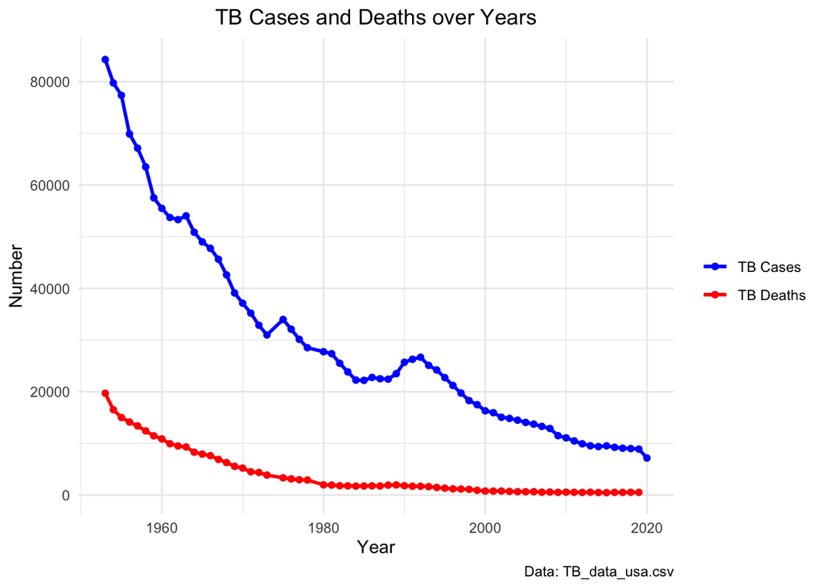

TB cases(Blue Line):  
- From 1953 to the 1980s, there was a sharp decline in TB cases, indicating that control over the disease improved over the years.  
- After the 1980s, the decline in TB cases slowed down, and the trend line showed minor peaks and troughs.  
- Toward the end of 2020, the number of TB cases did not decrease to zero, indicating that TB still remains a concern.

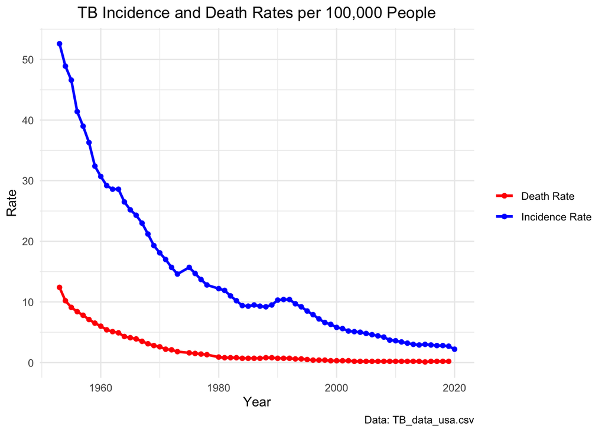

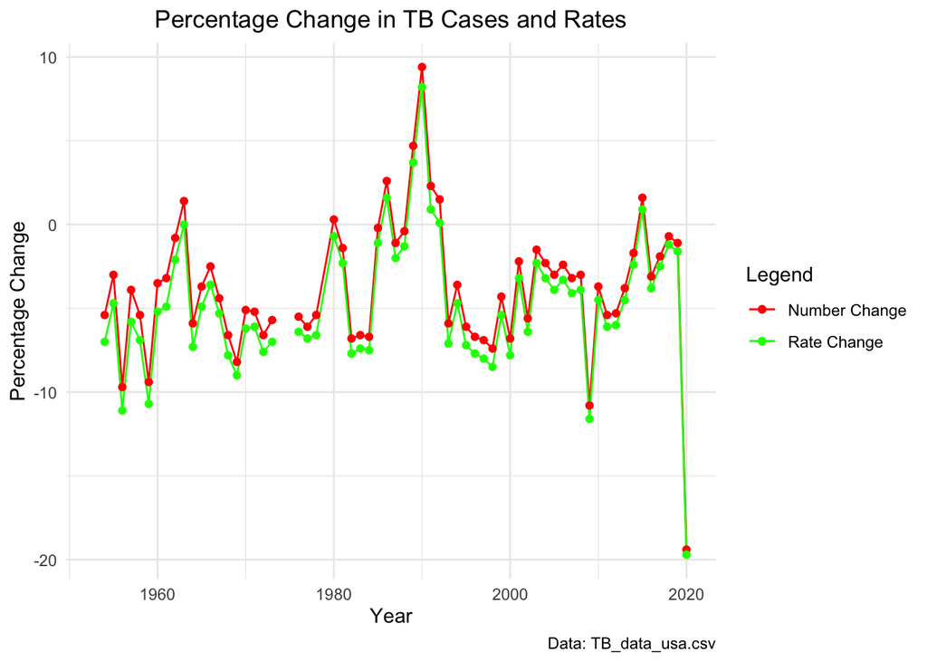

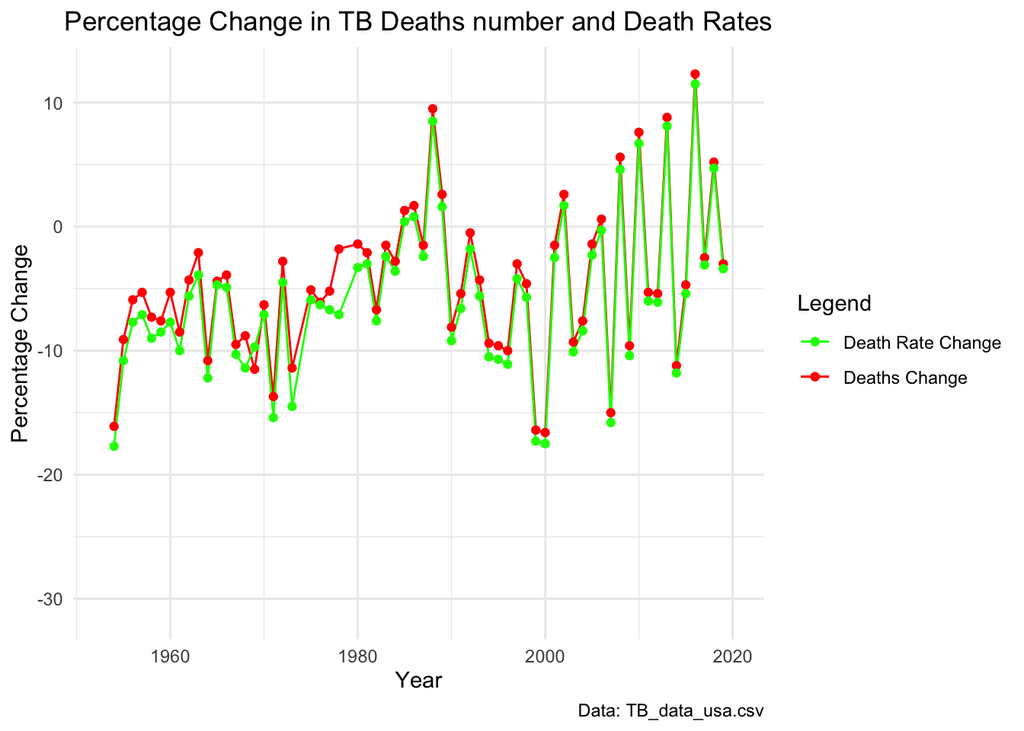

## Reference

[^1]: Explanation of Tuberculosis is learned from WHO
[^2]: Explanation of Tuberculosis is learned from WHO
[^3]: The dataset we got from https://www.cdc.gov/tb/statistics/reports/2020/table1.htm